# NoteBook EXAMEN PARCIAL

##### Realizado por:

- **Nestor Jardany Serrano Rojas**, [GitHub](https://github.com/jardanys/)
- **Camilo Alejandro Aguilar Laverde**, [GitHub](https://github.com/CamiloAguilar/)

# 1. Neuronal Network MNIST

A continuación se entrena un modelo por medio de maquinas de aprendizaje (redes neuronales), para la base de datos de MNIST, los números seleccionados para el modelo son **3** y **8**.

## 1.1. Selección de datos

A continuación se muestran los números seleccionados y se crea una base única para entrenamiento y pruebas.

```r
train_3 <- readRDS("./RDS/Train_3.rds")
train_8 <- readRDS("./RDS/Train_8.rds")

test_3 <- readRDS("./RDS/Test_3.rds")
test_8 <- readRDS("./RDS/Test_8.rds")

train_3_8 <- rbind(train_3, train_8)
test_3_8 <- rbind(test_3, test_8)
```

## 1.2. PCA aplicación bases de train y test

Con la base de entrenamiento se realiza un PCA y se muestra por componentes la varianza acumulada. Adicional con la función predict se crean las siguientes bases:

- Y para train
- Y para test
- X las características de train
- X las características de test

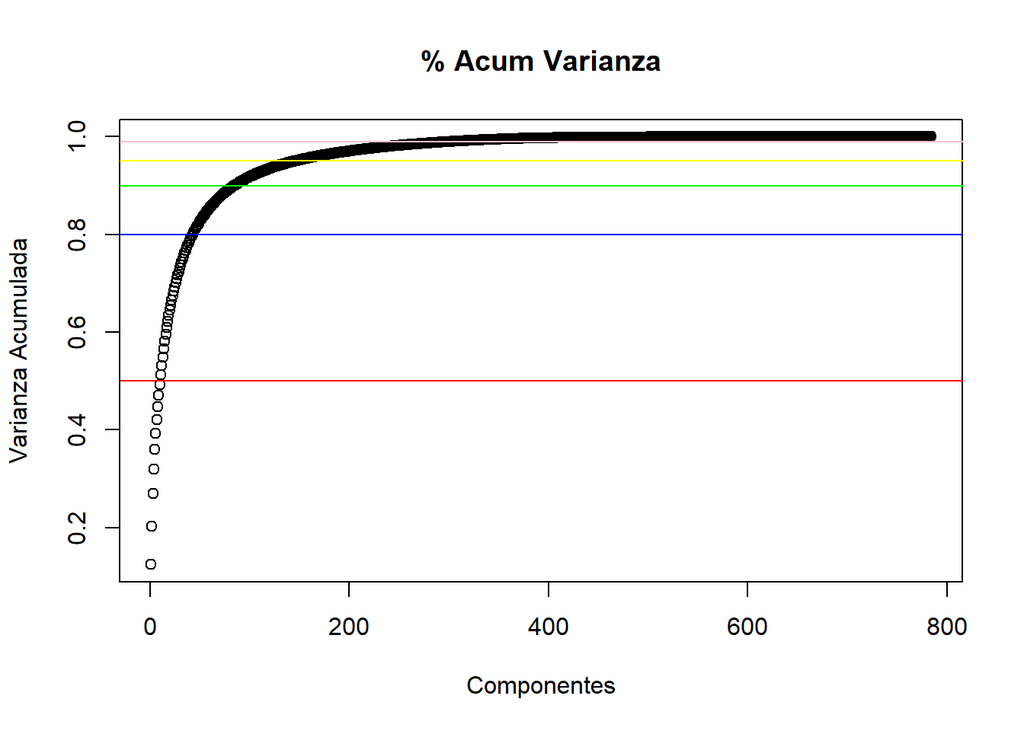

```r
pc <- prcomp(train_3_8[,c(1:784)])
pc_test <- predict(pc, test_3_8[,c(1:784)])
plot(cumsum(pc$sdev^2)/sum(pc$sdev^2), xlab = "Componentes", ylab = "Varianza Acumulada", main = "% Acum Varianza")
abline(h=0.5, col="red")
abline(h=0.8, col="blue")
abline(h=0.9, col="green")
abline(h=0.95, col="yellow")
abline(h=0.99, col="pink")
```

```r
x <- pc$x
x_test <- pc_test
y <- as.numeric(as.character(train_3_8[,785]))
y <- ifelse(y==3,1,0)
y_test <- as.numeric(as.character(test_3_8[,785]))
y_test <- ifelse(y_test==3,1,0)
```

## 1.3. Bucle para la red neuronal

Se crea un bucle teniendo en cuenta los siguientes parámetros:

- Componentes entre 2 y 100.
- Número de neuronas entre 1 y 10.

De acuerdo a los modelos desarrollados se obtiene crea una base de datos con los resultados de los modelos de acuerdo a los parámetros.

```r
componentes <- c(2:100)
neuronas <- c(1:10)
z <- 0
res <- data.frame(redes=0, componentes=1, neuronas=1, err=1)
library(progress)
pb <- progress_bar$new(total = 100)
for(i in componentes){
  for(j in neuronas){
    x <- pc$x[,c(1:i)]
    n_net <- nnet(y=y, x=x, size=j, trace=F, MaxNWts = 100000)
    predict.nnet <- round(predict(n_net, x_test[, c(1:i)]))
    error <- ifelse(predict.nnet==y_test, 0, 1)
    resid <- sum(error) / length(error)
    z <- z + 1
    res <- rbind(res, c(z, i, j, resid))
  }
  pb$tick()
}

res <- res[-1,]
res$err <- as.numeric(res$err)

kable(res, "html") %>%
  kable_styling("striped", full_width = F, position = "center") %>%
  scroll_box(width = "850px", height = "300px")
```

|  | redes | componentes | neuronas | err |
| --- | --- | --- | --- | --- |
| 2 | 1 | 2 | 1 | 0.1512097 |
| 3 | 2 | 2 | 2 | 0.1335685 |
| 4 | 3 | 2 | 3 | 0.1325605 |
| 5 | 4 | 2 | 4 | 0.1340726 |
| 6 | 5 | 2 | 5 | 0.1355847 |
| 7 | 6 | 2 | 6 | 0.1255040 |
| 8 | 7 | 2 | 7 | 0.1381048 |
| 9 | 8 | 2 | 8 | 0.1320565 |
| 10 | 9 | 2 | 9 | 0.1315524 |
| 11 | 10 | 2 | 10 | 0.1270161 |
| 12 | 11 | 3 | 1 | 0.1365927 |
| 13 | 12 | 3 | 2 | 0.1370968 |
| 14 | 13 | 3 | 3 | 0.1290323 |
| 15 | 14 | 3 | 4 | 0.1880040 |
| 16 | 15 | 3 | 5 | 0.1602823 |
| 17 | 16 | 3 | 6 | 0.1265121 |
| 18 | 17 | 3 | 7 | 0.1315524 |
| 19 | 18 | 3 | 8 | 0.1325605 |
| 20 | 19 | 3 | 9 | 0.1698589 |
| 21 | 20 | 3 | 10 | 0.1265121 |
| 22 | 21 | 4 | 1 | 0.1270161 |
| 23 | 22 | 4 | 2 | 0.1255040 |
| 24 | 23 | 4 | 3 | 0.1260081 |
| 25 | 24 | 4 | 4 | 0.1244960 |
| 26 | 25 | 4 | 5 | 0.1406250 |
| 27 | 26 | 4 | 6 | 0.1265121 |
| 28 | 27 | 4 | 7 | 0.1612903 |
| 29 | 28 | 4 | 8 | 0.1305444 |
| 30 | 29 | 4 | 9 | 0.1270161 |
| 31 | 30 | 4 | 10 | 0.1250000 |

[output cut: 960 more lines]

## 1.4. Mejor red neuronal

Se define con el modelo de red neuronal, el modelo con menor error de prueba, como se muestra a continuación.

```r
res[which.min(res$err),]
```

```
##     redes componentes neuronas        err
## 621   620          63       10 0.03780242
```

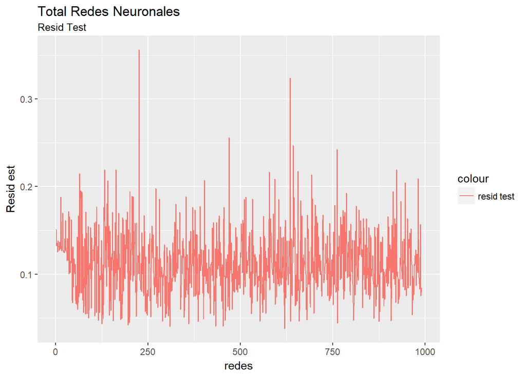

```r
ggplot(res, aes(x=redes, y=err, colour="resid test")) + geom_line() +
  ylab("Resid est") + labs(title = "Total Redes Neuronales",
                                    subtitle = "Resid Test")
```

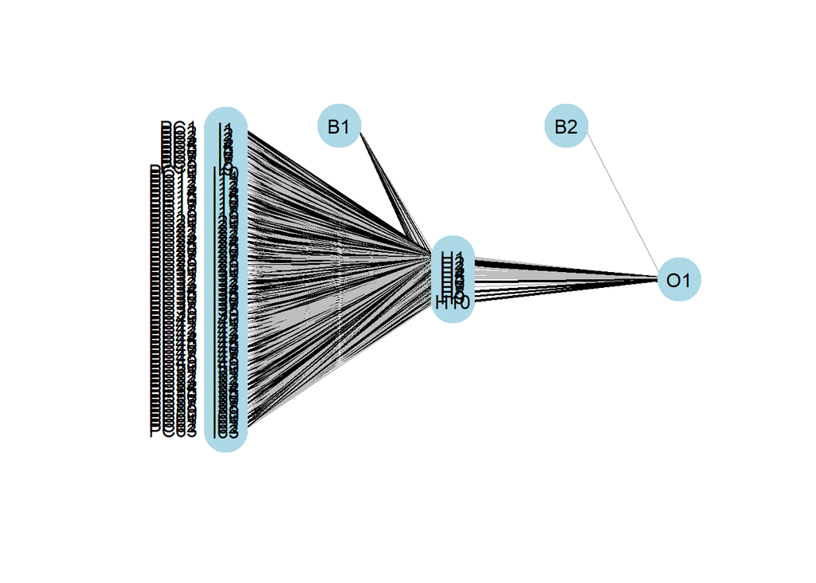

```r
compo <- res[which.min(res$err),2]
neu <- res[which.min(res$err),3]
x <- pc$x[,c(1:compo)]
n_net <- nnet(y=y, x=x, size=neu, trace=F, MaxNWts = 100000)
plot.nnet(n_net)
```

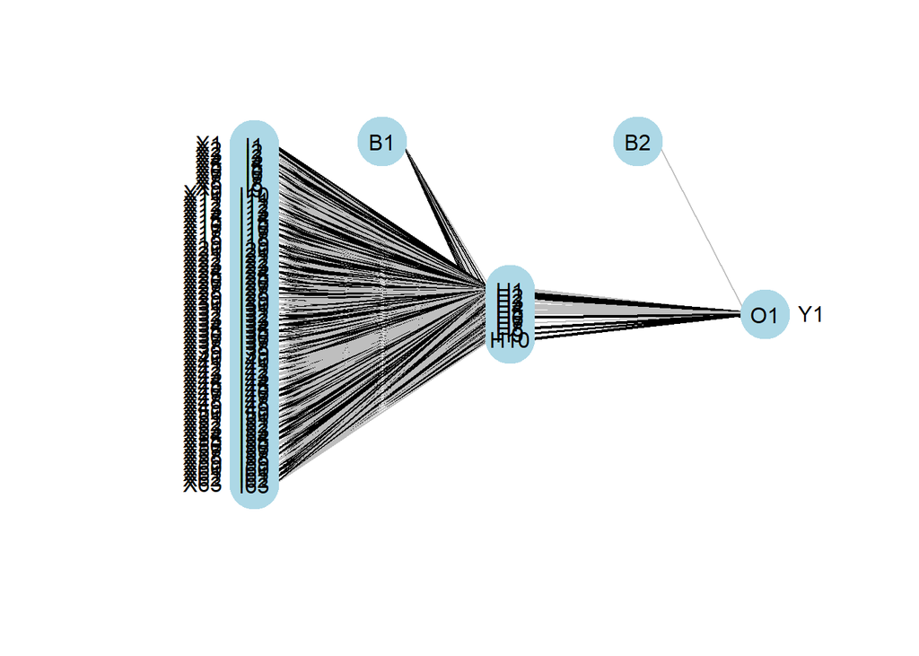

```r
wts.in<-n_net$wts
struct<-n_net$n
plot.nnet(wts.in,struct=struct)
```

# 2. Autoencoder

## 2.1. Mejor red neuronal

Por medio de la función de Autoencoder, para la base de perros y gatos se busca definir una reducción de dimensionalidad por medio del número de neuronas, aplicando más de una capa oculta. Así se realizan los siguientes pasos:

- Expresa la función para gráficas los perros o los gatos.
- Se generan 5 capas oculta, para un total de 7. COn 4 neuronas en la primera capa ocualta, 3 y 2 en las siguientes y luego se devuelven en número de neuronas.
- Se genera la imagen de un gato real
- Se genera la imagen del mismo gato con la función predict.autoencoder.

Entre más capas ocultas y mejor procesamiento de maquina la predicción puede mejorar.

```r
load("gatosperros.RData")

plotcd <- function(v){
  x <- matrix(v,64,64)
  image(1:65,1:65,t(apply(x,2,rev)),asp=1,xaxt="n",yaxt="n",
        col=grey((0:255)/255),ann=FALSE,bty="n")
}

auto_encode_9 <- autoencode(dm, unit.type = "logistic", N.hidden = c(4,3,2,3,4), nl = 7,
                          epsilon = 0.001, lambda = 0.0002, beta = 6, rho = 0.01)
```

```
## autoencoding...
```

```
## Optimizer counts:
## function gradient
##      356        2
## Optimizer: successful convergence.
## Optimizer: convergence = 0, message =
## J.init = 37851670, J.final = 37851602, mean(rho.hat.final) = 0.001999169
```

```r
predicion_autoencode_9 <- predict.autoencoder(auto_encode_9, dm)
```

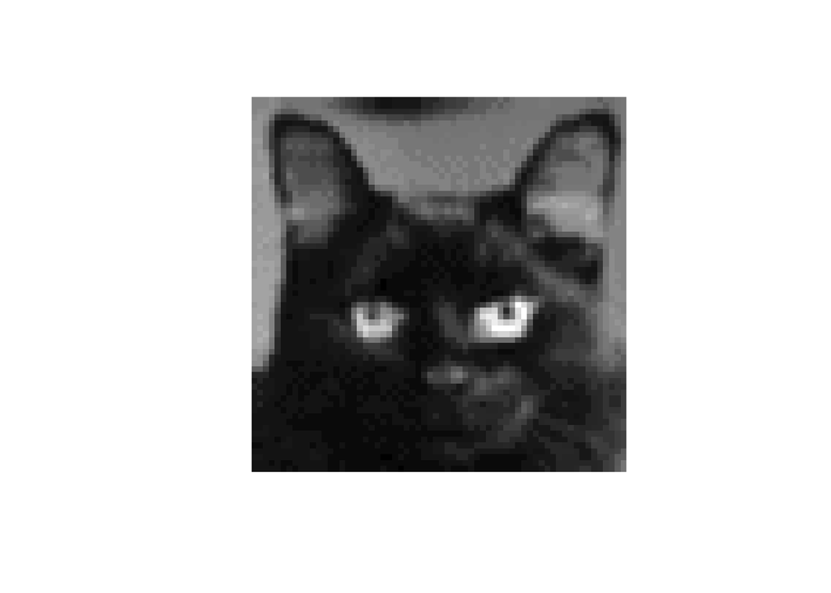

```r
plotcd(dm[3,])
```

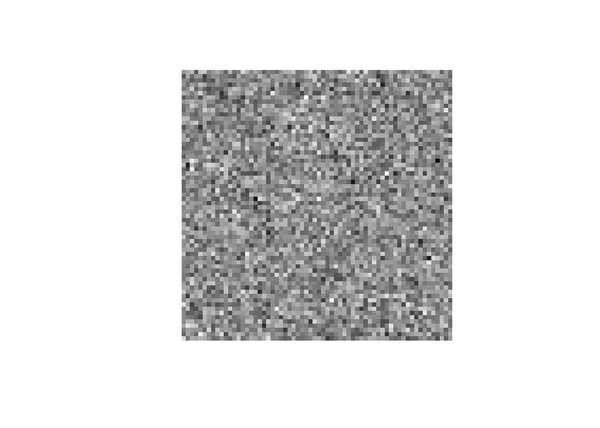

```r
plotcd(predicion_autoencode_9$X.output[3,])
```

2018-04 Universidad Santo Tomas

Copyright © All rights reserved.